# A visual story on the music listening habits of myself and close ones

STATS 220 Semester One, 2026

Nika Benyaminov

## The Goal

These plots track patterns in personal music listening behaviour, including how long listening sessions last, which genres are most frequently chosen, and when survey entries are logged. My aim was to understand better how our listening habits vary and whether any clear patterns emerge in how and when my group consumes music.

## How much listening actually happens at a time!

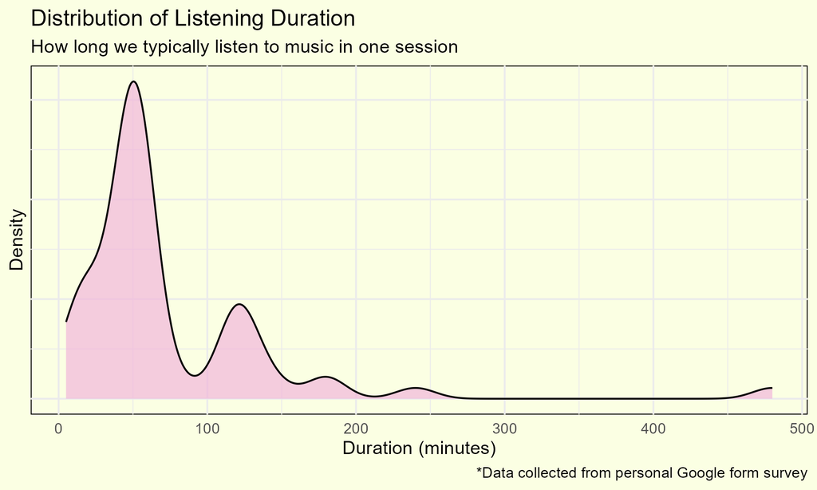

A pink and beige density plot showing what duration of music listening is most common per session. The title says “Distribution of listening duration”, the x axis is labelled “Duration (minutes), while the y axis is labelled”Density”. The plot itself peaks towards the left of the graph, where the most density is at around 50 minutes. The highest value is at around 470 minutes, at the very right end of the plot.

### The distribution of listening duration shows that most listening sessions are relatively short, with most density in the lower end of the scale, at approximately 50 minutes. This suggests that typical listening habits are made up of moderate length sessions rather than extremely short or continuous listening. One possible explanation is that there are many moments in ones routine where they have an hour free, such as a lunch break or daily bus-ride.

### The distribution is strongly right-skewed, with a small number of longer listening sessions stretching up to nearly 500 minutes. These outliers suggest occasional extended listening periods, possibly during study sessions or background listening. While the data indicates that medium sessions are most frequent, there is a wide variability in duration that could become more prominent if more data is collected for a longer time.

## Genre bias?!

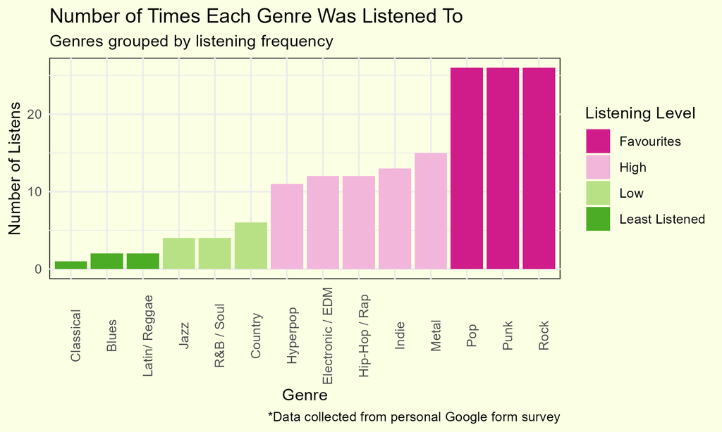

A colourful histogram (green and pink) displaying the frequency that each genre was picked to listen to. The title says “Number of Times Each Genre Was Listened To”, the x axis is labelled “Genre”, and the y axis “Number of Listens”. The bars are divided into four coloured sections depending on if they were in the lowest percent picked (dark green), low-high, and the most frequently picked (magenta). Pop, Punk and Rock are magenta and the tallest by far (over 20 picks), while Classical, Blues and Latin/Reggae are dark green and were not selected more than 5 times.

### Genre preference shows a clear preference in listening choices. Pop, Punk, and Rock are the clear favorites, each being selected far more frequently than other genres, with over 20 listens each. This suggests that my group of friends and I are actually quite aligned in our music taste!

### In contrast, genres such as Classical, Blues, and Latin/Reggae were rarely selected, each appearing fewer than five times. This indicates a strong preference in returning to familiar genres than an even exploration of other music. How stubborn!

## Logging time!

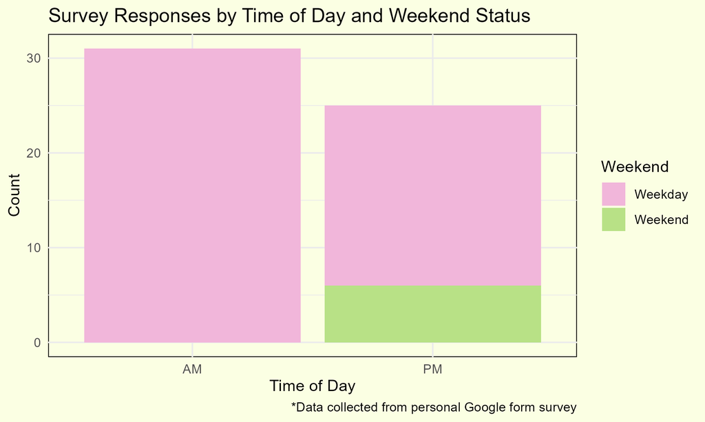

A pink and beige bar plot showing how many survey entries were logged during the morning (AM), versus PM, and whether it was a weekend or not. The title says “Survey Responses by Time of Day and Weekend Status”, the x axis is named “Time of Day”, and the y axis is named “Count”. The AM bar is slightly higher than the PM bar at about 30 entries. The bar of entries made during the weekday are pink, while those made on the weekend are green; the PM column has around 5 green, weekend entries, while the AM column has none.

### Survey responses were more commonly logged during the morning (AM) compared to the afternoon (PM), with AM entries slightly higher overall. This suggests that we may be more likely to complete logging earlier in the day, perhaps due to morning listening sessions like bus rides to campus or morning walks. One flaw of this display is the fact that some participants may have logged their responses after midnight, but not in the morning; scaling the AM column up.

### Weekend activity was notably lower, no weekend entries were made in the morning, and only a few (~5) in the afternoon. This demonstrates reduced engagement with the survey during weekends, one possible reason being weekend plans getting in the way of listening/ logging. Overall, the logging patterns dont seem to show a strong trend. I think the logging data would have been more useful if I encouraged logging right as the listening session concluded.